# Remote work and return to office discussions on Bluesky

Group 25 - Working report

Joshua William Kilpatrick

Alexander Manalo

Manraj Singh

# 1 Introduction

Our research questions were:

# 2 Analysis

## 2.1 Data collection and preparation

The keyword scripts use `atrrr` to request latest Bluesky posts for the phrases “return to office” and “remote work”. Although the current script requests 500 results per query, the saved raw files actually contain 592 RTO and 586 WFH records; the saved files, rather than the requested limit, define the observed sample. The existing cleaning script removes missing text, text of ten characters or fewer and repeated post URIs. It combines RTO first, so a URI appearing in both searches retains the RTO label. The resulting saved dataset contains 1,137 posts (577 RTO, 560 WFH). These labels describe search provenance, not an author’s preference.

Saved RTO post timestamps span 25 August to 29 September 2026; WFH timestamps span 15 to 29 September 2026 (UTC, ignoring missing timestamps). These are observed post-date ranges, not guaranteed collection windows. The different time coverage and latest-result selection limit direct population comparisons. This analysis reads the frozen files and does not collect fresh data.

For the text and clustering sections, we retain only posts with at least one language tag and with **every tag equal to `en` or an English regional variant** (case-insensitive). This leaves 751 English-labelled posts. We exclude 345 records without language tags and 41 with non-English or mixed tags. This is a metadata-based rule, not independent language verification; some excluded unlabelled posts may be English, and tagged posts may be mislabelled.

URLs, including bare domains and query strings, and account mentions are removed. Text is tokenised into lowercase words; English stop words, tokens containing non-ASCII letters or nonletters, and one-letter tokens are removed. Twenty-four English-labelled posts have no retained tokens, leaving **727 usable posts: 371 RTO and 356 WFH**. Full word forms are retained for readable descriptive charts. The per-post audit is saved in `outputs/text/inclusion_audit.csv`.

Text-analysis inclusion decisions by search group

| group | decision | posts |
| --- | --- | --- |
| RTO | Included | 371 |
| RTO | Missing language tag | 167 |
| RTO | No retained English word tokens | 17 |
| RTO | Non-English or mixed language tags | 22 |
| WFH | Included | 356 |
| WFH | Missing language tag | 178 |
| WFH | No retained English word tokens | 7 |
| WFH | Non-English or mixed language tags | 19 |

The earlier 20-post review identified political-office references, a Swedish post and link-only material. It was a diagnostic sample, not a complete relevance screen. No topic-based exclusions or text-based deduplication are applied here: distinct URIs can repeat the same message. Results therefore describe **English-labelled search results**, not a verified corpus of workplace-only discussion. The network section uses its own separately collected thread sample; these text-analysis filters do not alter it.

## 2.2 Text analysis

**Research question:** What vocabulary characterises the English-labelled RTO and WFH search results?

We use two complementary measures. Raw frequency counts every occurrence of a word; the post-level percentage counts a word only once per post and divides by the number of usable posts in that search group. Thus a word repeated several times in one post increases raw frequency but not post-level prevalence. These are descriptive comparisons, not hypothesis tests.

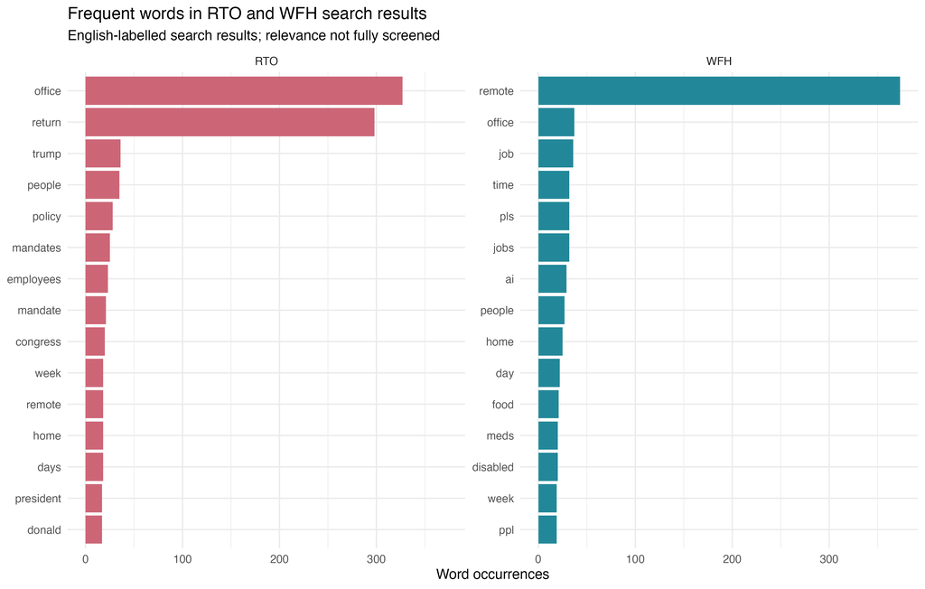

Top 15 words per search group by raw occurrences. Panels share a common count scale.

The frequent-word figure is dominated by terms connected to the queries, such as “return”, “office” and “remote”. This is partly a consequence of how the posts were retrieved and should not be presented as an independently discovered topic.

For the second figure only, we exclude `return`, `office`, `remote`, `work`, `home`, `rto`, `wfh` and `remotework`. Both panels use the same percentage scale; their denominators are 371 RTO posts and 356 WFH posts. Each panel shows its own top 15 terms, so an absent word is not necessarily absent from that group.

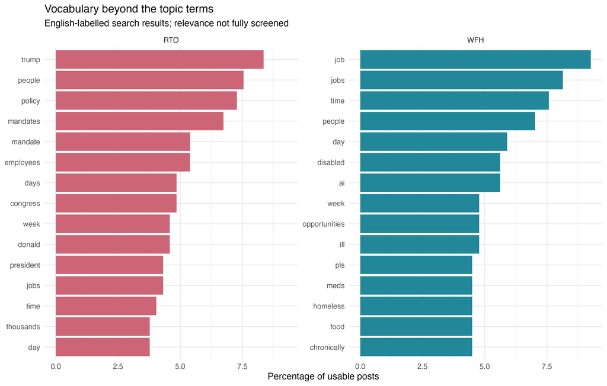

Percentage of usable posts mentioning each word, excluding topic-defining words. Word forms such as job/jobs and mandate/mandates are counted separately.

In RTO results, “policy” appears in 27 posts (7.3%), “mandates” in 25 (6.7%) and “employees” in 20 (5.4%). WFH results include “job” in 33 posts (9.3%), “jobs” in 29 (8.1%) and “time” in 27 (7.6%). These patterns suggest policy/employment vocabulary in RTO and job-related vocabulary in WFH. They do not establish support for either arrangement or the sentiment of the posts.

“Trump” occurs in 31 RTO posts (8.4%). Some political terms refer to genuine government workplace policies, while others come from unrelated political-office stories. Removing names alone would not resolve that distinction. Similarly, recruitment and repeated fundraising messages can contribute to WFH word counts. This motivates the clustering analysis: are the apparent themes broad patterns, or are some driven by repeated message families?

## 2.4 Clustering

**Research question:** Do the English-labelled search results form distinct vocabulary clusters, and how are the two search groups distributed across them?

### Representation and method

Starting with the same 727 usable posts, we remove the eight topic-defining terms used in the second word chart and apply English stemming with `SnowballC` (for example, employee/employees share a stem). We retain stems appearing in at least three posts to reduce one-off names and idiosyncratic vocabulary. This threshold is a modelling choice that can suppress rare themes. Twenty-seven posts become empty after these additional filters; all are recorded in `outputs/clustering/excluded_posts.csv`. The clustering matrix contains **700 posts and 811 stems**.

Term frequency is a stem’s count divided by the total count of retained stems in that post. Inverse document frequency is `log(N / df)`, where `N = 700` and `df` is the number of retained posts containing that stem. Their product is TF-IDF. We normalise each document vector to unit Euclidean length to reduce the effect of post length.

We run ordinary k-means using squared Euclidean distance on these normalised vectors, following the course’s TF-IDF, normalisation and k-means concepts. For two unit document vectors, squared Euclidean distance equals twice cosine dissimilarity. However, k-means centroids are not constrained to unit length, so this is **not spherical k-means or direct optimisation of cosine distance**. No two-dimensional projection is used to fit the clusters, and RTO/WFH labels are excluded from the input features.

### Number of clusters

For each `k` from 1 to 10, we use 30 random starts, at most 100 iterations and the reproducible seed `3020 + k`. We examine within-cluster sums of squares and representative text. The elbow curve has **no decisive bend**, so there is no strong evidence for one natural cluster count.

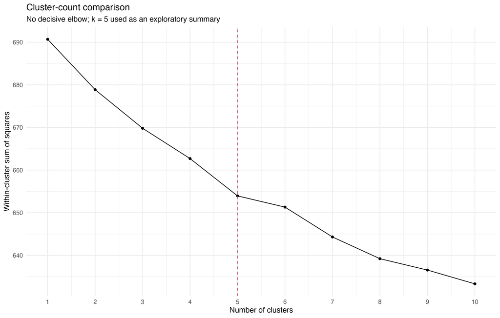

Within-cluster sums of squares for k = 1 to 10. The dashed line marks the exploratory five-cluster solution.

We select **k = 5 as an interpretable exploratory summary**. In the three-cluster run, 11 job-referral posts and ten auto-manufacturing news posts were combined. Five clusters separate these repeated families and also isolate another political-news group. The improvement from k = 4 to 5 is about 8.76 sum-of-squares units, compared with 2.63 from k = 5 to 6, but later reductions still occur. This is a pragmatic interpretation choice, not a claim of five well-separated workplace themes. The five-cluster solution accounts for only **5.32%** of total sum of squares between clusters.

### Cluster contents and search-group composition

We inspect the highest mean TF-IDF stems and actual posts, including the small clusters’ message families. Cluster numbers are ordered by decreasing size. Labels below are analyst descriptions; the algorithm supplies numbers, not meanings.

| Cluster | Posts | RTO | WFH | Interpretation |
| --- | --- | --- | --- | --- |
| 1 | 642 | 327 | 315 | Broad mixed remainder: workplace, policy, employment and other content |
| 2 | 21 | 21 | 0 | Repeated political-news wording, including stock-trading and investigation stories |
| 3 | 16 | 0 | 16 | Repeated fundraising/assistance appeals mentioning remote work |
| 4 | 11 | 0 | 11 | Repeated remote-job referral advertisements |
| 5 | 10 | 10 | 0 | Repeated auto-manufacturing news mentioning a president’s return to office |

Cluster 1 contains **91.7%** of the clustered posts. Its terms include `peopl`, `mandat`, `time`, `day`, `polici`, `job`, `employe` and `worker`. Nearby example posts discuss commuting costs, unequal access to home working and return-to-office requirements. This large cluster is heterogeneous and should not be treated as a single coherent theme.

Cluster 2 contains political-news language such as `trade`, `congress`, `stock`, `fbi` and `collin`. These describe the content of the posts, not independently verified news claims. Cluster 3 contains `pls`, `food`, `med`, `ppl` and `chronic`, reflecting repeated requests for assistance. Cluster 4 contains `cash`, `luck`, `mercor`, `extra` and `opportun`, reflecting job-referral promotions. Cluster 5 contains `reviv`, `promis`, `wave`, `struggl` and `upend`, reflecting repeated wording from one news story. The political-office families demonstrate query ambiguity rather than workplace preferences.

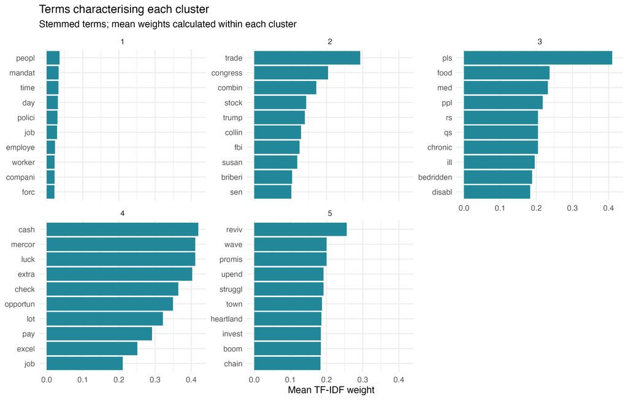

Ten highest mean TF-IDF stems per cluster. Stemming produces shortened forms; weights are averaged within each cluster.

The 11 referral posts have only three distinct cleaned token sequences; the 16 assistance posts have 13. These exact-sequence counts understate near-duplication because small wording changes create different sequences. Distinct URIs were retained, so repetition can drive a cluster. Cluster sizes are post counts, not counts of independent people or opinions.

### Visualisation and interpretation limits

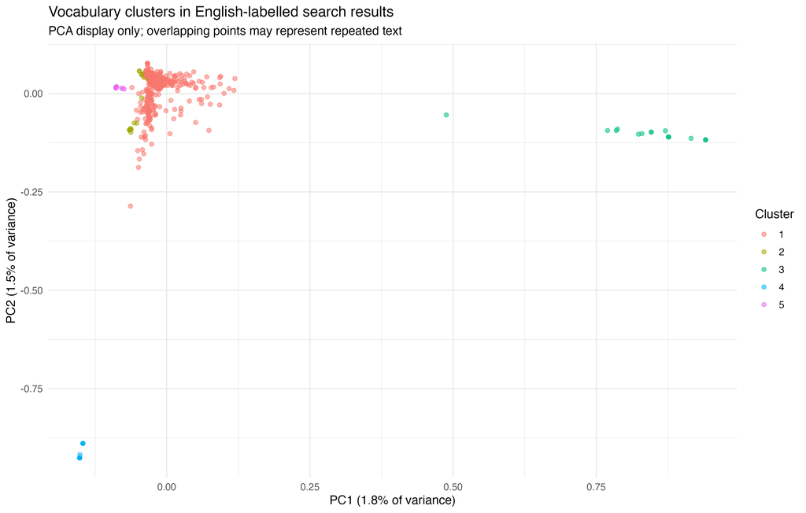

PCA display of clusters fitted in the full normalised TF-IDF space. Overlapping points can hide multiple posts.

The first two principal components explain only **1.78% and 1.52%** of variance, respectively (3.30% together). The plot is therefore a very limited projection; visible proximity or separation cannot establish the full clustering quality. Empty-post exclusions, stemming, vocabulary threshold, query-term removal, k and random initialisation all affect the solution. We have not established stability across datasets or a unique optimal solution.

Together, the text and clustering results show that query vocabulary and repeated content shape the apparent differences between groups. The analysis identifies some recurring message families but provides **weak evidence for broad, distinct workplace-discussion clusters**. A full relevance review, more balanced sampling and sensitivity to repeated text would be needed before drawing stronger conclusions about working arrangements.

## 2.5 Network analysis

We collected responses around three selected posts about working from home vs returning to the office to analyse how people interacted when discussing mental health, related costs, remote work and job competition.

### Data and graph construction

We requested the selected posts and up to two levels of replies, so we used replies to the selected post and replies to those replies. We did not request earlier posts higher up in the thread. We combined the saved responses while removing repeated posts using URIs, leaving 66 posts.

There were 62 different accounts in the network, and we added a connection from the replying account to the account it replied to when both posts were in the collected data.

Connections were excluded where the account was replying to itself. If connections between the same accounts were repeated in the same direction, we counted them only once, leaving 60 directed connections.

### Content review and scope

After reviewing the posts, we labelled 33 as workplace discussion, 26 as context, 6 as unclear and only 1 as off topic.

We used these labels to describe content rather than removing posts from the network.

the results show interactions for 3 selected posts and are not meant to represent preferences across Bluesky as a whole.

### Network structure

Structure of the observed reply network

| Measure | Value |
| --- | --- |
| Retrieved posts | 66 |
| Accounts | 62 |
| Directed edges | 60 |
| Directed density | 0.0159 |
| Isolated accounts | 0 |
| Weak components | 3 |
| Largest component: accounts | 32 |

The network density was 0.0159. This means about 1.59% of the possible directed connections between different accounts were present.

The network had three connected groups, called weak components, containing 32, 19 and 11 accounts. We identified these groups by checking which accounts were connected while ignoring the direction of the arrows. We did not observe any connections between the three groups in the collected data.

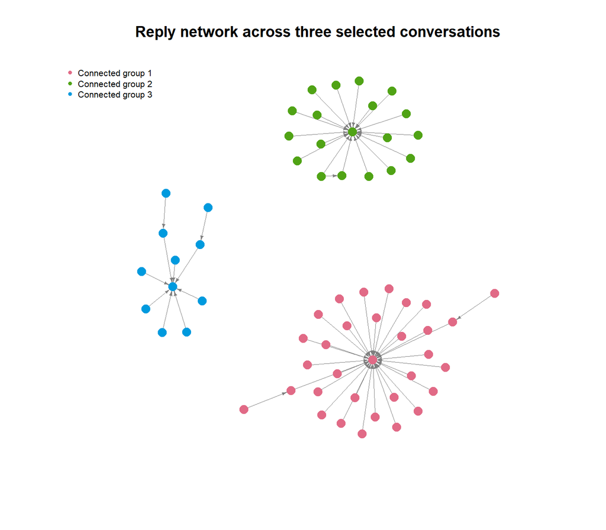

Observed reply network across three selected conversations (62 accounts, 60 edges). Arrows point from replying authors to parent authors; colours identify weak components.

### Largest connected conversation

We chose the largest weak component to get a clearer view of the conversation with the most accounts. Its selected post discussed workplace isolation and mental health. This group contained 32 accounts and 31 directed connections. We calculated the network statistics and centrality scores using the full network.

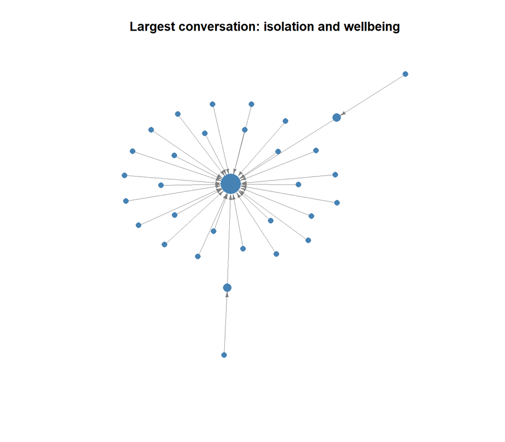

Largest weak component: isolation and wellbeing (32 accounts, 31 edges). Node size increases with in-degree.

### Account centrality

We used two centrality measures: in-degree and raw, or unnormalised, directed betweenness. The table shows the three accounts with the highest in-degree and all accounts with a betweenness score above zero.

Accounts with the three highest in-degrees or positive directed betweenness

| Account | In-degree | Raw betweenness |
| --- | --- | --- |
| cnn.com | 29 | 0 |
| rincewind.run | 18 | 0 |
| shockemc.bsky.social | 8 | 0 |
| goodboy.bsky.social | 1 | 1 |
| nasboat.org | 1 | 1 |
| nk-dizzle.bsky.social | 1 | 1 |
| trekkiebill.bsky.social | 1 | 1 |

In-degree counts how many different accounts have a reply connection pointing to an author. The accounts cnn.com, rincewind.run and shockemc.bsky.social received connections from 29, 18 and eight different accounts respectively. These accounts wrote the three selected posts, so the way we collected the conversations favours them as reply targets. Replies indicate engagement within these conversations, but they do not establish agreement or endorsement.

Directed betweenness measures an account’s role on the shortest paths between other accounts, following the direction of the arrows. The accounts at the start and end of a path are not counted as intermediaries. The three accounts with the highest in-degree all had a betweenness score of zero. Receiving many replies therefore did not mean they acted as links between other accounts.

The accounts goodboy.bsky.social, nasboat.org, nk-dizzle.bsky.social and trekkiebill.bsky.social each had a raw betweenness score of one. These small scores show a limited role as intermediaries within the recorded reply paths. They do not show that these accounts connect the three separate groups or have influence across Bluesky.

### Limitations

We used 3 selected posts to collect replies, so the network does not show all the reply connections these accounts may have. Our requests went as far as two reply levels, excluding posts from higher up in the thread. Before we added a reply connection, both posts had to be collected. Connections might therefore have been left out because the posts were outside our requests or because the API didn’t return them. The inclusion of more complete data could potentially change the groups and centrality scores.

Most replies were around the selected posts. With only two reply levels, there are few longer paths for betweenness to measure. This means the scores partly reflect how we collected the data. The 3 groups could be linked by replies we did not collect. They do not tell us which work arrangement people support or how common those opinions are across Bluesky.

The text and context did not give us enough information to label 6 posts more clearly. We did not check media, so that information is missing from our content review. We still kept all 66 posts, including the unclear and off-topic ones. An account’s colour or position on the graph does not tell us its workplace preference. These network review counts come from a separate sample from the group’s keyword-based content analysis.

# 3 Discussion

# 4 Conclusion

# 5 References

**Project repository:** https://github.com/AlexanderManalo19385596/comp3020-bluesky-rto-wfh

# Appendix: text and clustering code

## 05_text_analysis.R

```r
# RQ: How does vocabulary differ between English-labelled RTO/WFH search results?
library(dplyr)
library(tidyr)
library(tidytext)
library(stringr)
library(ggplot2)
dir.create("outputs/text", recursive = TRUE, showWarnings = FALSE)

# Language metadata is supplied by Bluesky; missing/mixed tags are not English-only.
posts <- readRDS("data/posts_clean.rds")
language_codes <- lapply(posts$langs, function(x) tolower(unlist(x)))
audit <- posts |> select(uri, group, text)
audit$language <- vapply(language_codes, paste, collapse = ";", FUN.VALUE = "")
audit$english <- vapply(language_codes, function(x) {
  length(x) > 0 && all(grepl("^en(-[a-z]+)?$", x))
}, logical(1))
# Remove URLs (also bare domains/short links) and account mentions before tokenising.
url_pattern <- regex("https?://\\S+|www\\.\\S+|\\b[a-z0-9][a-z0-9.-]*\\.[a-z]{2,}(?:[/?#]\\S*)?", TRUE)
audit$clean_text <- audit$text |>
  str_remove_all(url_pattern) |>
  str_remove_all("@[[:alnum:]_.-]+") |>
  str_replace_all("[’‘]", "'")
words <- audit |> filter(english) |> select(uri, group, clean_text) |>
  unnest_tokens(word, clean_text) |>
  anti_join(stop_words, by = "word") |>
  filter(str_detect(word, "^[a-z]+$"), nchar(word) >= 2)
audit <- audit |> mutate(
  usable = english & uri %in% words$uri,
  decision = case_when(!english & language == "" ~ "Missing language tag",
    !english ~ "Non-English or mixed language tags",
    !usable ~ "No retained English word tokens", TRUE ~ "Included"))
text_posts <- audit |> filter(usable)
text_counts <- audit |> count(group, decision, name = "posts")
word_counts <- words |> count(group, word, sort = TRUE)
# These are search-result groups, not verified opinions or a relevance-screened corpus.
topic_words <- c("return", "office", "remote", "work", "home", "rto", "wfh", "remotework")
post_word_rates <- words |> filter(!word %in% topic_words) |>
  distinct(uri, group, word) |> count(group, word, name = "posts_with_word") |>
  left_join(text_posts |> count(group, name = "total_posts"), by = "group") |>
  mutate(percent = 100 * posts_with_word / total_posts)

# Both figures share a numeric scale across groups; top 15 terms are chosen per group.
plot_words <- function(data, metric, title, axis_label) {
  top <- data |> mutate(value = .data[[metric]]) |> group_by(group) |>
    arrange(desc(value), word, .by_group = TRUE) |> slice_head(n = 15) |> ungroup()
  ggplot(top, aes(reorder_within(word, value, group), value, fill = group)) +
    geom_col(show.legend = FALSE) + facet_wrap(~group, scales = "free_y") +
    scale_x_reordered() + coord_flip() + theme_minimal(base_size = 12) +
    scale_fill_manual(values = c(RTO = "#CC6677", WFH = "#228899")) +
    labs(title = title, subtitle = "English-labelled search results; relevance not fully screened",
         x = NULL, y = axis_label)
}
word_plot <- plot_words(word_counts, "n", "Frequent words in RTO and WFH search results", "Word occurrences")
rate_plot <- plot_words(post_word_rates, "percent", "Vocabulary beyond the topic terms", "Percentage of usable posts")
print(word_plot)
print(rate_plot)
ggsave("outputs/text/word_frequency.png", word_plot, width = 11, height = 7, dpi = 300, bg = "white")
ggsave("outputs/text/post_word_percentages.png", rate_plot, width = 11, height = 7, dpi = 300, bg = "white")
write.csv(audit, "outputs/text/inclusion_audit.csv", row.names = FALSE)
write.csv(text_counts, "outputs/text/sample_counts.csv", row.names = FALSE)
write.csv(word_counts, "outputs/text/word_counts.csv", row.names = FALSE)
write.csv(post_word_rates, "outputs/text/post_word_percentages.csv", row.names = FALSE)
saveRDS(list(posts = text_posts, words = words, topic_words = topic_words), "outputs/text/analysis_input.rds")
writeLines(capture.output(sessionInfo()), "outputs/text/session_info.txt")
print(text_counts)
```

## 07_clustering.R

```r
# RQ: Do English-labelled search results contain distinct vocabulary clusters?
# Run 05_text_analysis.R first. Module 6: TF-IDF, k-means and elbow analysis.
library(dplyr)
library(tidytext)
library(SnowballC)
library(ggplot2)
dir.create("outputs/clustering", recursive = TRUE, showWarnings = FALSE)
a <- readRDS("outputs/text/analysis_input.rds")
# Remove query-defining words and stem English words; keep terms in >=3 posts.
counts <- a$words |> filter(!word %in% a$topic_words) |>
  mutate(term = wordStem(word, language = "english")) |> count(uri, term, name = "n")
vocabulary <- counts |> count(term, name = "documents") |> filter(documents >= 3)
counts <- counts |> semi_join(vocabulary, by = "term")
M <- unclass(xtabs(n ~ uri + term, counts))
# TF = within-post term proportion; IDF = log(N / document frequency).
T <- sweep(M / rowSums(M), 2, log(nrow(M) / colSums(M > 0)), "*")
stopifnot(all(rowSums(T^2) > 0), all(is.finite(T)))
X <- T / sqrt(rowSums(T^2))
# Ordinary k-means uses squared Euclidean distance on unit-length TF-IDF rows.
# Pairwise squared Euclidean distance / 2 equals cosine dissimilarity here.
# This is NOT spherical k-means: centroids are not constrained to unit length.
fits <- lapply(1:10, function(k) {
  set.seed(3020 + k)
  kmeans(X, centers = k, nstart = 30, iter.max = 100)
})
elbow <- data.frame(k = 1:10, within_ss = sapply(fits, function(f) f$tot.withinss))
elbow$reduction <- c(NA, -diff(elbow$within_ss))
# No decisive elbow: k=5 separates repeated referral/news families mixed at k=3.
# This is an interpretable exploratory cut, not evidence of five natural themes.
chosen_k <- 5
candidate_summary <- bind_rows(lapply(2:10, function(k) {
  bind_rows(lapply(1:k, function(j) {
    idx <- which(fits[[k]]$cluster == j)
    groups <- a$posts$group[match(rownames(X)[idx], a$posts$uri)]
    terms <- names(sort(colMeans(T[idx, , drop = FALSE]), decreasing = TRUE))[1:8]
    data.frame(k = k, cluster = j, posts = length(idx), RTO = sum(groups == "RTO"),
               WFH = sum(groups == "WFH"), top_stems = paste(terms, collapse = ", "))
  }))
}))
fit <- fits[[chosen_k]]
# Relabel in decreasing size so C1 is always the largest cluster.
cluster <- match(fit$cluster, order(fit$size, decreasing = TRUE))
assignments <- a$posts[match(rownames(X), a$posts$uri), c("uri", "group", "text")]
assignments$cluster <- cluster
centres <- do.call(rbind, lapply(1:chosen_k, function(j) colMeans(X[cluster == j, , drop = FALSE])))
assignments$distance_to_centre <- rowSums((X - centres[cluster, ])^2)
top_terms <- bind_rows(lapply(1:chosen_k, function(j) {
  data.frame(cluster = j, term = colnames(T), weight = colMeans(T[cluster == j, , drop = FALSE])) |>
    arrange(desc(weight), term) |> slice_head(n = 10)
}))
examples <- assignments |> group_by(cluster) |>
  arrange(distance_to_centre, uri, .by_group = TRUE) |> slice_head(n = 5) |> ungroup()
cluster_summary <- assignments |> count(cluster, group) |> group_by(cluster) |>
  mutate(cluster_size = sum(n), percent = 100 * n / cluster_size) |> ungroup()
# Diagnose identical processed text within clusters; different URIs remain separate posts.
repetition <- a$words |> group_by(uri) |> summarise(signature = paste(word, collapse = " ")) |>
  inner_join(assignments |> select(uri, cluster), by = "uri") |> group_by(cluster) |>
  summarise(posts = n(), unique_token_sequences = n_distinct(signature), .groups = "drop")
# PCA is for display only. Clusters were fitted in all retained term dimensions.
pca <- prcomp(X, center = TRUE, scale. = FALSE, rank. = 2)
variance <- 100 * pca$sdev^2 / sum(pca$sdev^2)
coords <- data.frame(PC1 = pca$x[, 1], PC2 = pca$x[, 2], cluster = factor(cluster))
elbow_plot <- ggplot(elbow, aes(k, within_ss)) + geom_line() + geom_point() +
  geom_vline(xintercept = chosen_k, linetype = "dashed", colour = "#CC6677") +
  scale_x_continuous(breaks = 1:10) + theme_minimal(base_size = 12) +
  labs(title = "Cluster-count comparison", subtitle = "No decisive elbow; k = 5 used as an exploratory summary",
       x = "Number of clusters", y = "Within-cluster sum of squares")
cluster_plot <- ggplot(coords, aes(PC1, PC2, colour = cluster)) +
  geom_point(alpha = 0.55, size = 1.7) + theme_minimal(base_size = 12) +
  labs(title = "Vocabulary clusters in English-labelled search results",
       subtitle = "PCA display only; overlapping points may represent repeated text",
       x = sprintf("PC1 (%.1f%% of variance)", variance[1]),
       y = sprintf("PC2 (%.1f%% of variance)", variance[2]), colour = "Cluster")
term_plot <- ggplot(top_terms, aes(reorder_within(term, weight, cluster), weight)) +
  geom_col(fill = "#228899") + facet_wrap(~cluster, scales = "free_y") +
  scale_x_reordered() + coord_flip() + theme_minimal(base_size = 12) +
  labs(title = "Terms characterising each cluster", x = NULL, y = "Mean TF-IDF weight",
       subtitle = "Stemmed terms; mean weights calculated within each cluster")
for (name in c("elbow", "cluster", "term")) {
  figure <- get(paste0(name, "_plot"))
  print(figure)
  ggsave(paste0("outputs/clustering/", name, ".png"), figure, width = 11, height = 7, dpi = 300, bg = "white")
}
excluded <- a$posts |> filter(!uri %in% assignments$uri) |>
  select(uri, group, text) |> mutate(reason = "No terms after topic-word and document-frequency filters")
metrics <- data.frame(posts = nrow(X), terms = ncol(X), k = chosen_k,
  excluded_after_text = nrow(excluded), explained_between_percent = 100 * fit$betweenss / fit$totss,
  pc1_percent = variance[1], pc2_percent = variance[2])
# Save all result tables using the same output convention.
results <- list(assignments = assignments, top_terms = top_terms, examples = examples,
  cluster_summary = cluster_summary, elbow = elbow, repetition = repetition,
  candidate_summary = candidate_summary, excluded_posts = excluded, metrics = metrics)
for (name in names(results)) write.csv(results[[name]],
  paste0("outputs/clustering/", name, ".csv"), row.names = FALSE)
saveRDS(list(fit = fit, cluster = cluster, uris = rownames(X), terms = colnames(X)),
        "outputs/clustering/model.rds")
writeLines(capture.output(sessionInfo()), "outputs/clustering/session_info.txt")
print(metrics)
print(cluster_summary)
```